# SF Bikes

Disha Gupta

11/11/2018

Load all the relevant libraries:

Load all the required packages. Pacman ensures to download the packages that don’t already exist.

```r
if (!require("pacman")) install.packages("pacman")
pacman::p_load(readr,dplyr,ggplot2,caret,ranger,stringr,data.table,leaflet)
options(scipen=999)
```

Set the working directory and read all the files

```r
setwd("~/Downloads/sf-bay-area-bike-share")
station <- read_csv("station.csv")
#status <- read_csv("status.csv") #coudn't make use of it
trip <- read_csv("trip.csv")
weather <- read_csv("weather.csv")
```

Let’s do some exploratory analysis on the data Top 10 stations with most trip starts:

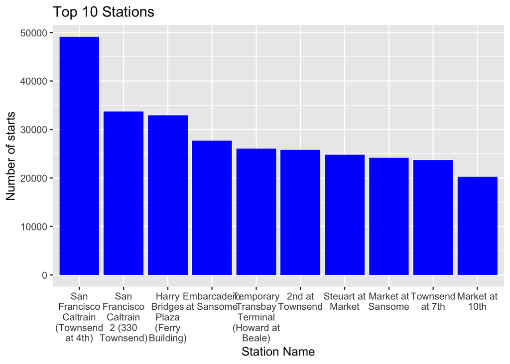

```r
#Stations with most starts
Starts = trip %>% group_by(start_station_id) %>% summarise(Starts=n())
Starts = merge(Starts,station,by.x="start_station_id",by.y="id")
Starts = Starts %>% top_n(10,Starts)
ggplot(Starts,aes(x=reorder(name,-Starts),y=Starts))+geom_bar(stat = "identity",fill="blue")+
  xlab("Station Name")+ylab("Number of starts")+ggtitle("Top 10 Stations")+theme_grey(base_size = 12)+
  scale_x_discrete(labels = function(x) str_wrap(x, width = 10))
```

Let’s visualize the location of the Top 10 stations with most starts. Green is the most, red is the least within top 10.

```r
pal <- colorNumeric(
  palette = colorRampPalette(c('red', 'green'))(length(Starts$Starts)),
  domain = Starts$Starts)
Starts$popup=paste(Starts$name,": ",Starts$Starts)
leaflet(data = Starts) %>% addTiles() %>%
  #addMarkers(~Longitude, ~Latitude,icon=DivyIcon,label = ~StationName,popup = ~NoOfStarts) %>%
  addCircles(~long, ~lat,
             radius = 100,#radius = ~NoOfStarts/2000,
             fillOpacity = 0.7,weight = 200,col=~pal(Starts),popup = ~popup,label = ~Starts,
             stroke = FALSE
  ) %>% addLabelOnlyMarkers(~long, ~lat, label = ~popup,labelOptions = labelOptions(noHide = T,
                                                                                              textOnly = TRUE,
                                                                                              textsize = "12px",direction = "top"))
```

[interactive chart not shown]

The subscribers on an average have shorter trips than the customers. This is expected because subscribers usually commute for work whereas the customers commute to explore the city.

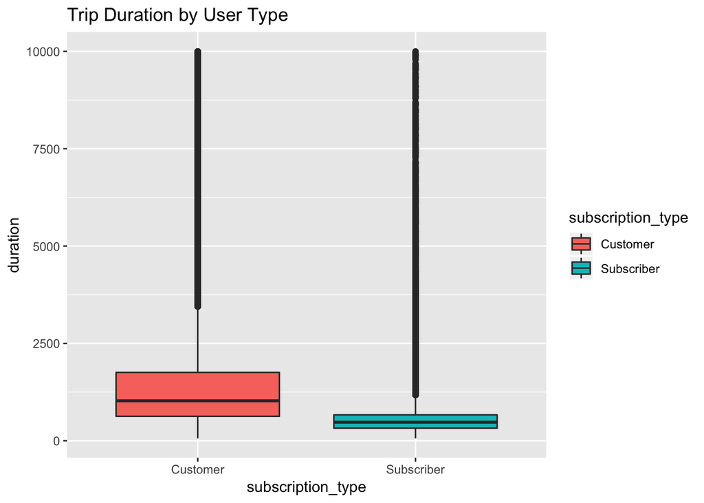

```r
#Trip duration by user type
UserTypeDuration = trip %>% group_by(subscription_type) %>% summarise(MinDuration=min(duration),
                                                                MaxDuration=max(duration),
                                                                MeanDuration=mean(duration),
                                                                MedianDuration=median(duration),Count=n())
ggplot(trip[trip$duration<10000,c("subscription_type","duration")], aes(x=subscription_type, y=duration)) +
  geom_boxplot(aes(fill=subscription_type))+ggtitle("Trip Duration by User Type")
```

The total count of trips for subscribers is much more than those by customers as well.

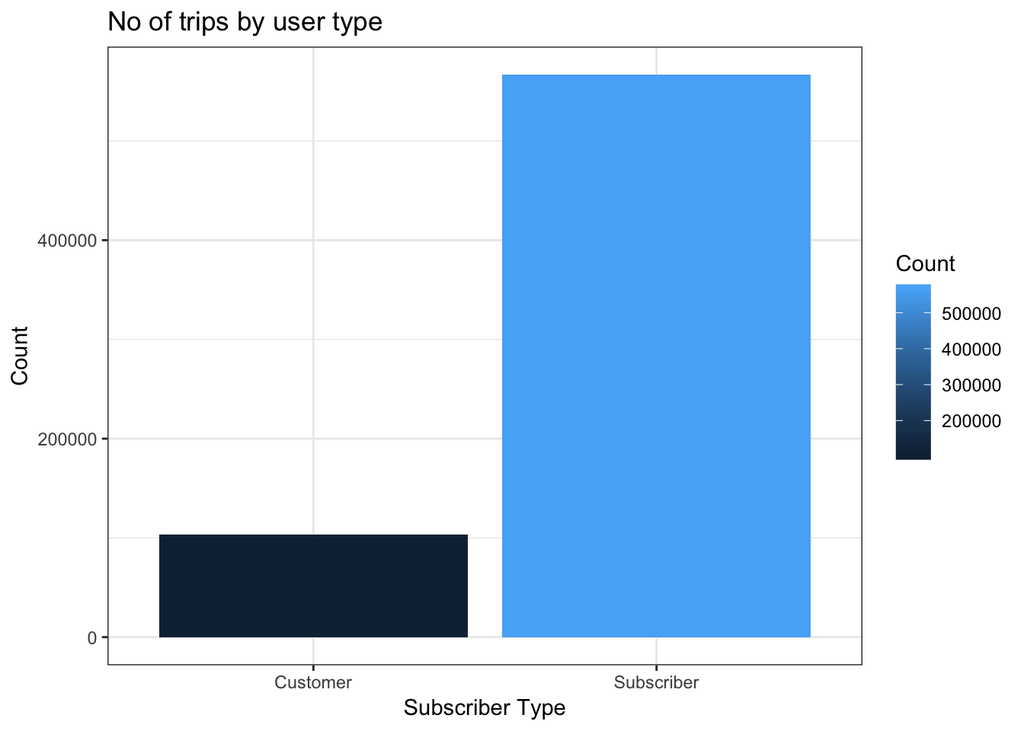

```r
ggplot(UserTypeDuration, aes(subscription_type, Count))+geom_bar(stat = "identity", aes(fill = Count)) +
  xlab("Subscriber Type") + ylab("Count") +
  ggtitle("No of trips by user type") +
  theme_bw()
```

The next block of code shows which station stretches, end to end are the most popular ones. The green stretch has the highest number of trips. Do press the “+” in the map to zoom in the three clusters of areas with top stretches.

```r
#Most popular trips - stretches
Trips = trip %>% group_by(start_station_id,end_station_id) %>% summarise(Trips=n())
#remove the trips with same start and stop station
Trips = Trips[Trips$end_station_id!=Trips$start_station_id,]
Trips <- data.table(Trips)
# Following mnel's suggestion, g1, g2 could be used directly in by
# and it could be even shortened by using `id1` and id2` as their names
Trips <- Trips[, list(Trips=sum(Trips)),
               by=list(id1 = pmin(start_station_id, end_station_id), id2 = pmax(start_station_id, end_station_id))]

Trips = merge(Trips,station[,c("id","long","lat")],by.x="id1",by.y="id")
colnames(Trips)[colnames(Trips)=="long"]="start_long"
colnames(Trips)[colnames(Trips)=="lat"]="start_lat"
Trips = merge(Trips,station[,c("id","long","lat")],by.x="id2",by.y="id")
colnames(Trips)[colnames(Trips)=="long"]="end_long"
colnames(Trips)[colnames(Trips)=="lat"]="end_lat"
Trips=as.data.frame(Trips)
Trips = Trips %>% top_n(20,Trips)
PopularStations=unique(c(Trips$id1,Trips$id2))
PopularMAP=station[station$id %in% PopularStations,]

Trips$floorPop <- floor(rank((Trips$Trips)))
colours <- seq(1, floor(max(rank((Trips$Trips)))))
colours <- colorRampPalette(c("darkred","yellow","darkgreen"))(length(colours))
Trips$colour=NULL
Trips <- merge(Trips,
               data.frame(Pop = 1:length(colours),
                          colour = colours),
               by.x = "floorPop",
               by.y = "Pop")
m<-leaflet(data = PopularMAP) %>% addTiles() %>%
  addLabelOnlyMarkers(~long, ~lat, label = ~name,
                      labelOptions = labelOptions(noHide = T,
                                                  #textOnly = TRUE,
                                                  textsize = "10px",
                                                  direction = "right"))
for (i in 1:nrow(Trips)) {
  m<-m %>% addPolylines(lat=c(Trips[i,]$start_lat,Trips[i,]$end_lat),lng=c(Trips[i,]$start_long,Trips[i,]$end_long),
                        color = Trips[i,]$colour)}#weight = popular[i,]$Popularity/5000,
m
```

[interactive chart not shown]

Following are some of the busiest bikes of all by total duration after removing the outliers:

```r
#Busiest Bike
Bikes = trip %>% filter(duration < 12*60*60) %>%
  group_by(bike_id) %>% summarise(Count=n(),TotalDuration=sum(duration)/60,AvgDuration=mean(duration)/60)
Bikes %>% top_n(5,TotalDuration) %>% arrange(desc(TotalDuration))
```

```
## # A tibble: 5 x 4
##   bike_id Count TotalDuration AvgDuration
##     <int> <int>         <dbl>       <dbl>
## 1     613  1864         32587        17.5
## 2     553  1744         31130        17.8
## 3     587  1793         30812        17.2
## 4     625  1851         30657        16.6
## 5     518  1939         30573        15.8
```

Overall weekdays are more popular than weekends:

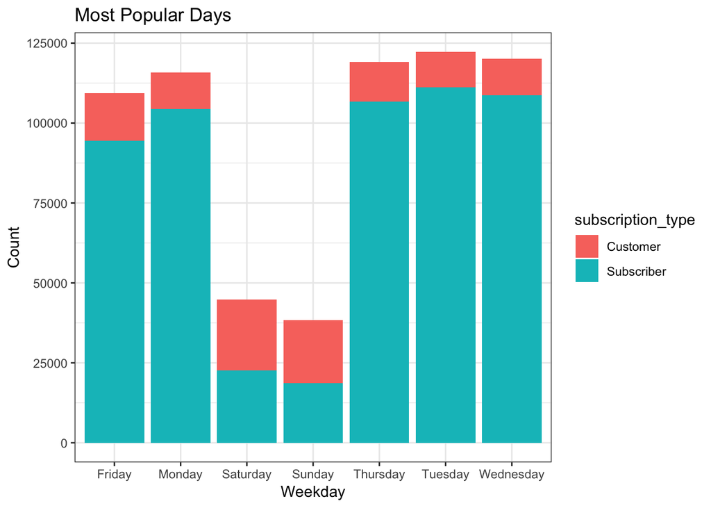

```r
#hour and date for starts
trip$start_hour = as.numeric(format(strptime(trip$start_date,"%m/%d/%Y %H:%M"),'%H'))
trip$start_date = as.Date(trip$start_date,format = "%m/%d/%Y %H:%M")
#peak hours,days, months
trip$day=weekdays(trip$start_date)
PeakHours = trip %>% group_by(start_hour,subscription_type) %>% summarise(count=n())
PeakDays = trip %>% group_by(day,subscription_type) %>% summarise(count=n())
p <-ggplot(PeakDays, aes(day, count))
p +geom_bar(stat = "identity", aes(fill = subscription_type)) +
  xlab("Weekday") + ylab("Count") +
  ggtitle("Most Popular Days") +
  theme_bw()
```

The most popular hours also tie up with the work-start (8-9am) and end-time (5-6pm) for subscribers:

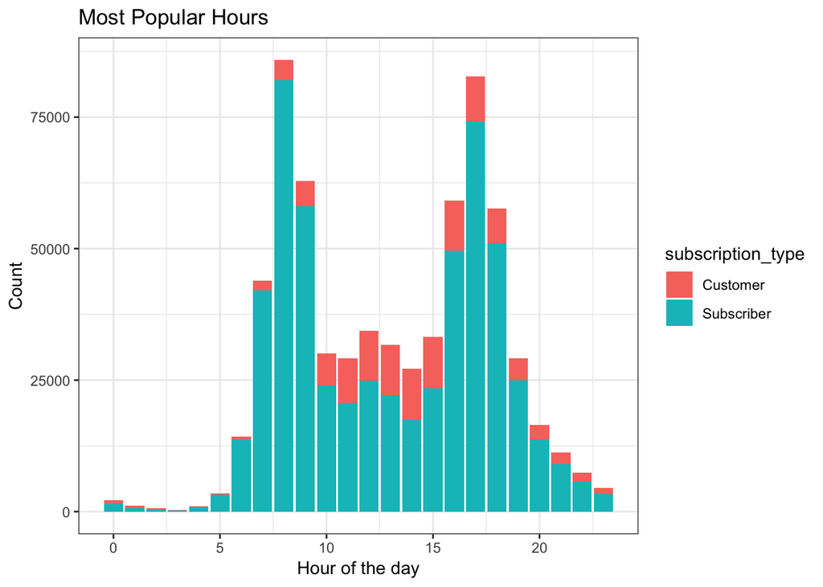

```r
p <-ggplot(PeakHours, aes(start_hour, count))
p +geom_bar(stat = "identity", aes(fill = subscription_type)) +
  xlab("Hour of the day") + ylab("Count") +
  ggtitle("Most Popular Hours") +
  theme_bw()
```

The winter months are less busy than the other months:

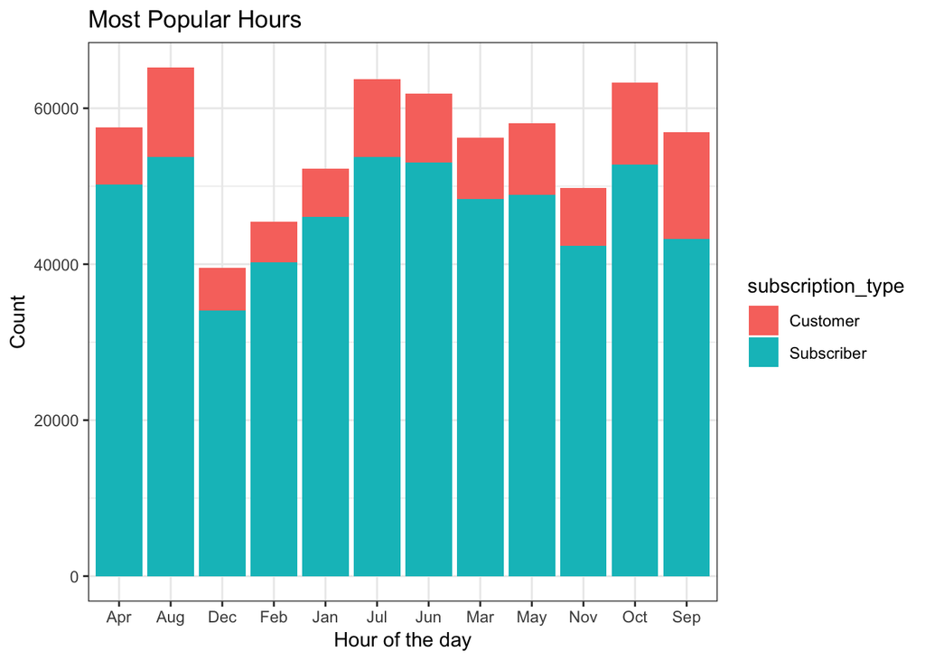

```r
trip$month=months.Date(trip$start_date,abbreviate = TRUE)
PeakMonth=trip %>% group_by(month,subscription_type) %>% summarise(count=n())
p <-ggplot(PeakMonth, aes(month, count))
p +geom_bar(stat = "identity", aes(fill = subscription_type)) +
  xlab("Hour of the day") + ylab("Count") +
  ggtitle("Most Popular Hours") +
  theme_bw()
```

In the follwoing piece, we will predict the number of trips from each station on a given day so that the operator can plan number of bikes on the dock. We will use features such as month, day of the week, weather features, previous 1-7 day trips etc to make these predictions.

Tried to include the weather features at zip code level, but the weather data isn’t as granular as the stations data - aggregated it at the date level.

Also tried to make predictions at the hourly level, but it would have been impossible for the operator to plan number of bikes at a given station by hour. So, making the predictions a day in advance would help them prepare the station with the optimal number of bikes.

```r
Data = trip %>% group_by(start_date,start_station_id,subscription_type) %>% summarise(Trips=n())
Data$DayMinus1=Data$start_date-1
Data$DayMinus2=Data$start_date-2
Data$DayMinus3=Data$start_date-3
Data$DayMinus4=Data$start_date-4
Data$DayMinus5=Data$start_date-5
Data$DayMinus6=Data$start_date-6
Data$DayMinus7=Data$start_date-7
Data=merge(Data,rename(Data[,c("start_date","start_station_id","Trips","subscription_type")],DayMinusTrips1=Trips),by.x = c("DayMinus1","start_station_id","subscription_type"),
           by.y=c("start_date","start_station_id","subscription_type"),all.x = T)
Data=merge(Data,rename(Data[,c("start_date","start_station_id","Trips","subscription_type")],DayMinusTrips2=Trips),by.x = c("DayMinus2","start_station_id","subscription_type"),
           by.y=c("start_date","start_station_id","subscription_type"),all.x = T)
Data=merge(Data,rename(Data[,c("start_date","start_station_id","Trips","subscription_type")],DayMinusTrips3=Trips),by.x = c("DayMinus3","start_station_id","subscription_type"),
           by.y=c("start_date","start_station_id","subscription_type"),all.x = T)
Data=merge(Data,rename(Data[,c("start_date","start_station_id","Trips","subscription_type")],DayMinusTrips4=Trips),by.x = c("DayMinus4","start_station_id","subscription_type"),
           by.y=c("start_date","start_station_id","subscription_type"),all.x = T)
Data=merge(Data,rename(Data[,c("start_date","start_station_id","Trips","subscription_type")],DayMinusTrips5=Trips),by.x = c("DayMinus5","start_station_id","subscription_type"),
           by.y=c("start_date","start_station_id","subscription_type"),all.x = T)
Data=merge(Data,rename(Data[,c("start_date","start_station_id","Trips","subscription_type")],DayMinusTrips6=Trips),by.x = c("DayMinus6","start_station_id","subscription_type"),
           by.y=c("start_date","start_station_id","subscription_type"),all.x = T)
Data=merge(Data,rename(Data[,c("start_date","start_station_id","Trips","subscription_type")],DayMinusTrips7=Trips),by.x = c("DayMinus7","start_station_id","subscription_type"),
           by.y=c("start_date","start_station_id","subscription_type"),all.x = T)
Data[is.na(Data)]=0
Data$Day=weekdays(Data$start_date)
Data$Month=months(Data$start_date)
```

Following was the work done on extracting zip codes from the lat and long of stations, but was eventually not used because of the weather data granularity

```r
# library(RCurl)
# library(RJSONIO)
# library(zoo)
#
# latlon2zip <- function(lat, lon) {
#   url <- sprintf("http://nominatim.openstreetmap.org/reverse?format=json&lat=%f&lon=%f&zoom=18&addressdetails=1", lat, lon)
#   res <- fromJSON(url)
#   return(res[["address"]][["postcode"]])
# }
#
# station$Zip="NA"
# for ( i in 1:nrow(station)){
#   tryCatch({
# zip <- latlon2zip(lat=station$lat[i], lon=station$long[i])
# print(zip)
# station$Zip[i]=zip
#   }, error=function(e){})
# }
#
# station$Zip[station$Zip=="NA"] <- NA
# station=station %>% arrange(lat,long)
# station$Zip <- na.locf(station$Zip)
# station$Zip=gsub("-*","",station$Zip)
# station$Zip=substr(station$Zip,1,5)

#Data=merge(Data,station[,c("id","Zip")],by.x="start_station_id",by.y="id")
```

```r
weather$date=as.Date(weather$date,format="%m/%d/%Y")

Mode <- function(x) {
  ux <- unique(x)
  ux[which.max(tabulate(match(x, ux)))]
}
weather$precipitation_inches=as.numeric(weather$precipitation_inches)
weatherAggregate = weather %>% group_by(date) %>% summarise(max_temp=max(max_temperature_f,na.rm = T),
                                                            mean_temp=mean(mean_temperature_f,na.rm = T),
                                                            min_temp=min(min_temperature_f,na.rm = T),
                                                            max_dew=max(max_dew_point_f,na.rm = T),
                                                            mean_dew=mean(mean_dew_point_f,na.rm = T),
                                                            min_dew=min(min_dew_point_f,na.rm = T),
                                                            max_humidity=max(max_humidity,na.rm=T),
                                                            min_humidity=min(min_humidity,na.rm = T),
                                                            mean_humidity=mean(mean_humidity,na.rm = T),
                                                            min_visibility=min(min_visibility_miles,na.rm=T),
                                                            max_visibility=max(max_visibility_miles,na.rm=T),
                                                            mean_visibility=mean(mean_visibility_miles,na.rm=T),
                                                            events=Mode(events),
                                                            precipitation_inches=median(precipitation_inches,na.rm = T),
                                                            cloud_cover=median(cloud_cover,na.rm=T),
                                                            max_wind_speed=max(max_wind_Speed_mph,na.rm=T),
                                                            mean_wind_speed=mean(mean_wind_speed_mph,na.rm = T))
```

```r
Data=merge(Data,weatherAggregate,by.x="start_date",by.y = "date")
```

```r
Data$events[is.na(Data$events)]="NA"

character_vars <- lapply(Data, class) == "character"
Data[, character_vars] <- lapply(Data[, character_vars], as.factor)
colnames(Data) <- make.names(colnames(Data), unique=TRUE)
Data=Data[complete.cases(Data),]
Data$start_date=Data$DayMinus6=Data$DayMinus1=Data$DayMinus5=Data$DayMinus4=Data$DayMinus3=Data$DayMinus2=Data$DayMinus7=NULL

#Data=Data %>% group_by(start_station_id,subscription_type) %>% mutate(AvgStarts=mean(Trips))
```

```r
trainIndex <- createDataPartition(Data$Trips, p = 0.8, list=FALSE, times=1)
subTrain <- Data[trainIndex,]
subTest <- Data[-trainIndex,]
formula <- Trips~.
```

Let’s fit a simple linear regression model with 5 fold cross validation. The R2 is 86%

```r
tcontrol2 <- trainControl(method = "cv", number = 5)
fit2      <- train(formula, data=subTrain, method = "lm", metric = "RMSE", trControl = tcontrol2)
fit2$results
```

```
##   intercept     RMSE  Rsquared      MAE  RMSESD  RsquaredSD      MAESD
## 1      TRUE 5.413166 0.8552251 3.309402 0.14128 0.005187071 0.03906694
```

Let’s try to fit random forest model while tuning hyperparameters with 5 fold cross validation - R2 of 92%

```r
# tgrid <- expand.grid(
#     .mtry = 4:6,
#     .splitrule = "variance",
#     .min.node.size = c(5,10,15)
# )
#choosing the winning set of hyper parameters to speed up the code
 tgrid <- expand.grid(
     .mtry = 6,
     .splitrule = "variance",
     .min.node.size = c(5)
)
fit.rf.cv <- train(formula, data=subTrain , method='ranger', trControl=trainControl(method="cv", number = 5, verboseIter = T,allowParallel= FALSE),metric='RMSE',importance = 'impurity',num.trees=100,tuneGrid=tgrid)
fit.rf.cv$results
```

```
##   mtry splitrule min.node.size     RMSE  Rsquared      MAE    RMSESD
## 1    6  variance             5 4.128393 0.9168644 2.496013 0.1859136
##    RsquaredSD      MAESD
## 1 0.006563847 0.02712507
```

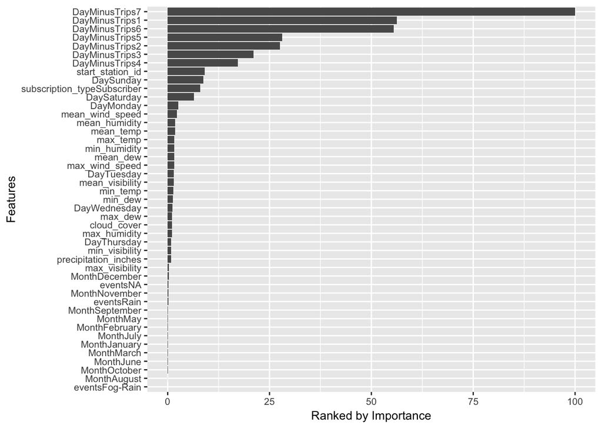

```r
#Variable Importance Plot
ggplot(varImp(fit.rf.cv),show.legend=FALSE) +
  geom_bar(stat='identity')+
  coord_flip() + xlab("Features") +ylab("Ranked by Importance") +
  theme(text = element_text(size=10),legend.position="none")
```

With this model, given the previous days trips, day of the week, weather etc, we can predict the total number of trips by subscriber type for each station id. This daily model can be used by the operator to optimize the daily bike placement.